# Machine Learning-Based Prediction of Dry Eye Disease from Lifestyle and Ocular Metrics

Harshini Muthukumar

12-04-2025

## Introduction

**Dry Eye Disease (DED)** is a common ocular condition influenced by behavioral, lifestyle, and environmental factors. This project uses a structured dataset containing key variables such as sleep quality, sleep duration, screen time, eye strain, itchiness, eye redness, and blue-light filter usage to build predictive models for DED diagnosis. The dataset includes subjects aged 18 to 45, allowing analysis of patterns associated with ocular surface health.

Beyond detecting DED, the dataset also provides opportunities to study additional sleep-related disorders—such as insomniavthat may be linked to ocular surface diseases (OSD).

### Primary Goal

The primary goal of this project is to develop **accurate and interpretable machine learning models for predicting the presence of Dry Eye Disease (DED)** based on lifestyle and ocular-related attributes. The project focuses on identifying key predictors that contribute to DED, evaluating the impact of sleep patterns and screen usage on ocular health, and comparing the performance of multiple machine learning models to determine the most effective diagnostic tool. Additionally, an ensemble modeling approach is employed to improve predictive performance and achieve a more balanced and reliable classification.

## Data Exploration

### Separating Blood Pressure Into Systolic and Diastolic Numeric Features

```r
ded <- ded %>%
  mutate(Blood.pressure = as.character(Blood.pressure),
         Systolic = as.numeric(sub("/.*", "", Blood.pressure)),
         Diastolic = as.numeric(sub(".*/", "", Blood.pressure))) %>%
  select(-Blood.pressure)

# Check result
#str(ded[, c("Systolic", "Diastolic")])
summary(ded$Systolic)
```

```
##    Min. 1st Qu.  Median    Mean 3rd Qu.    Max.
##      90     102     115     115     128     140
```

```r
summary(ded$Diastolic)
```

```
##    Min. 1st Qu.  Median    Mean 3rd Qu.    Max.
##      60      67      75      75      83      90
```

### Creating BMI as a Derived Feature From Height and Weight

```r
ded <- ded %>%
  mutate(BMI = Weight / ( (Height/100)^2 ))
#str(ded)
```

### Plot 1 - Distribution of Dry Eye Disease

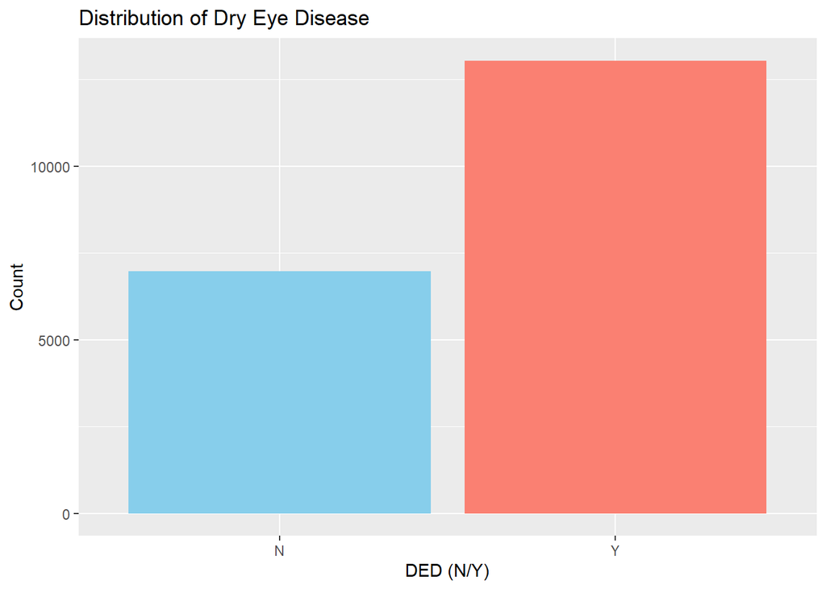

### Plot 2 - Sleep Disorder vs Dry Eye Disease

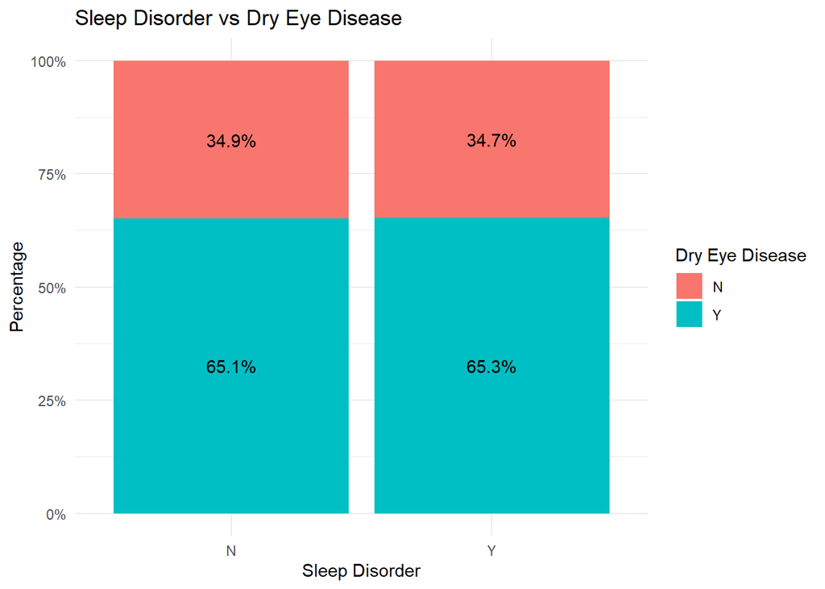

### Plot 3 - Distribution of BMI Across Dry Eye Disease Groups

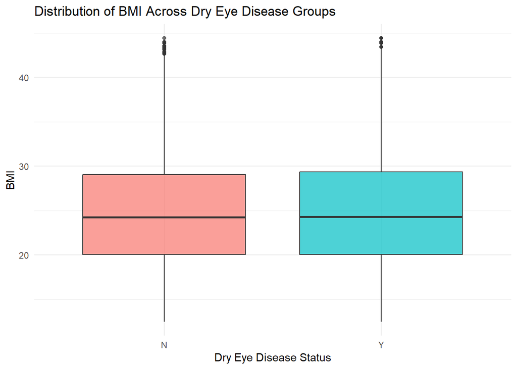

### Correlation

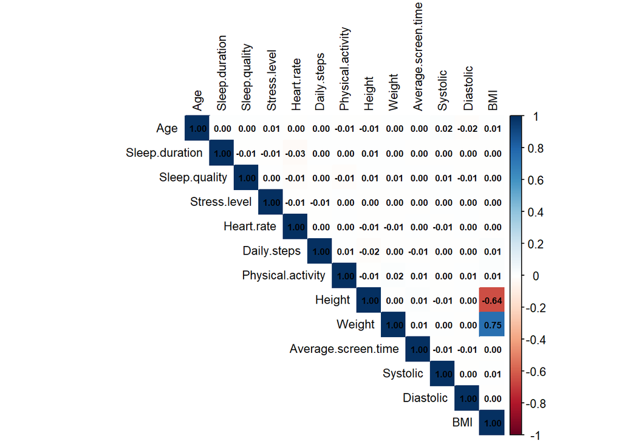

### Chi-square Analysis

```
## Top 5 Important Predictors:
```

```
##                                Variable Chi_Square df      p_value
## X-squared11       Discomfort.Eye.strain 240.950875  1 2.439911e-54
## X-squared12              Redness.in.eye 213.439551  1 2.440515e-48
## X-squared13 Itchiness.Irritation.in.eye 204.808114  1 1.864895e-46
## X-squared                        Gender   5.259404  1 2.182849e-02
## X-squared9      Smart.device.before.bed   3.492883  1 6.163317e-02
```

```
##
## Top 5 Least Important Predictors:
```

```
##                        Variable   Chi_Square df   p_value
## X-squared8   Ongoing.medication 0.3334726763  1 0.5636214
## X-squared4 Caffeine.consumption 0.1486132897  1 0.6998641
## X-squared1       Sleep.disorder 0.1264386471  1 0.7221535
## X-squared7        Medical.issue 0.0190140847  1 0.8903261
## X-squared2 Wake.up.during.night 0.0008812841  1 0.9763171
```

## Data Cleaning and Shaping

```
## [1] 0
```

```
##    Sleep.duration       Daily.steps Physical.activity        Heart.rate
##                 0                 0               117                 0
##          Systolic         Diastolic               BMI
##                 0                 0                 0
```

### Identification of Outlier

```r
# Select numeric columns
numeric_cols <- sapply(ded, is.numeric)
numeric_data <- ded[, numeric_cols]

# Function to count outliers using 1.5*IQR rule
count_outliers <- function(x) {
  Q1 <- quantile(x, 0.25)
  Q3 <- quantile(x, 0.75)
  IQR <- Q3 - Q1
  lower <- Q1 - 1.5 * IQR
  upper <- Q3 + 1.5 * IQR
  sum(x < lower | x > upper)
}

# Apply to all numeric columns
outlier_counts <- sapply(numeric_data, count_outliers)

# View results
outlier_counts
```

```
##                 Age      Sleep.duration       Sleep.quality        Stress.level
##                   0                   0                   0                   0
##          Heart.rate         Daily.steps   Physical.activity Average.screen.time
##                   0                   0                   0                   0
##            Systolic           Diastolic                 BMI
##                   0                   0                  50
```

## Model Construction and Evaluation

### Train-Test Split

```
##
##  Random Forest (ded)
```

```
## Training set class distribution:
```

```
##
##         N         Y
## 0.3481894 0.6518106
```

```
##
## Test set class distribution:
```

```
##
##        N        Y
## 0.348058 0.651942
```

### Baseline Logistic Regression: Training and Evaluation

```r
#Predict on test set

pred_probs <- predict(log_model_cv, test, type = "prob")[, "Yes"] # probability of positive class
pred_class <- predict(log_model_cv, test)# predicted class


#Evaluate performance
cm <- confusionMatrix(pred_class, test$Dry.Eye.Disease, positive = "Yes")

# Extract metrics
accuracy  <- cm$overall['Accuracy']
precision <- cm$byClass['Pos Pred Value']
recall    <- cm$byClass['Sensitivity']
f1        <- 2 * (precision * recall) / (precision + recall)

cat("\nConfusion Matrix:\n")
```

```
##
## Confusion Matrix:
```

```r
print(cm$table)
```

```
##           Reference
## Prediction   No  Yes
##        No  1242 1759
##        Yes  846 2152
```

```r
cat("\nMetrics:\n")
```

```
##
## Metrics:
```

```r
cat("Accuracy :", round(accuracy, 3), "\n")
```

```
## Accuracy : 0.566
```

```r
cat("Precision:", round(precision, 3), "\n")
```

```
## Precision: 0.718
```

```r
cat("Recall   :", round(recall, 3), "\n")
```

```
## Recall   : 0.55
```

```r
cat("F1 Score :", round(f1, 3), "\n")
```

```
## F1 Score : 0.623
```

The baseline logistic regression model demonstrates moderate predictive ability, reflected by an accuracy of 0.566, indicating that around 56.6% of the test samples were classified correctly. **Precision of 0.718 suggests that when the model predicts “Yes” for Dry Eye Disease, the prediction is correct about 71.8% of the time**, reflecting relatively strong reliability for positive predictions. However, the recall of 0.55 shows that only about 55% of actual Dry Eye Disease cases were successfully identified, indicating that many positive cases were missed.

**The F1 score of 0.623, which balances precision and recall**, confirms intermediate overall performance. These results are consistent with a baseline model trained without threshold adjustment or advanced tuning, and highlight opportunities for improvement, particularly in increasing sensitivity to better capture true positive cases.

### Tuned Logistic regression: Training and Evaluation

```r
# TrainControl with 5-fold CV and SMOTE
ctrl_tuned <- trainControl(
  method = "cv",
  number = 5,
  sampling = "smote",
  classProbs = TRUE,
  summaryFunction = twoClassSummary
)

# Create Bagged Logistic Regression Function
bagged_logistic_tuned <- function(train_data, B = 10) {

  models_tuned <- list()

  set.seed(123)

  for (b in 1:B) {
    # Bootstrap sample
    idx <- sample(1:nrow(train_data), replace = TRUE)
    boot_sample <- train_data[idx, ]

    # Train logistic regression on bootstrap sample
    model_b_tuned <- train(
      Dry.Eye.Disease ~ .,
      data = boot_sample,
      method = "glm",
      family = binomial(),
      trControl = ctrl_tuned,
      metric = "ROC"
    )

    models_tuned[[b]] <- model_b_tuned

  }

  return(models_tuned)
}

# Train 10 bagged logistic regression models
bag_log_models_tuned <- bagged_logistic_tuned(train, B = 10)

# Predict on test set (averaging probabilities)
test_probs_matrix_tuned <- sapply(bag_log_models_tuned, function(m) {
  predict(m, test, type = "prob")[, "Yes"]
})

# Average predicted probability across all bagged models
avg_pred_probs_tuned <- rowMeans(test_probs_matrix_tuned)

# Apply threshold = 0.3
threshold_tuned <- 0.3

pred_class_bag_tuned <- ifelse(avg_pred_probs_tuned >= threshold_tuned, "Yes", "No")
pred_class_bag_tuned <- factor(pred_class_bag_tuned, levels = c("No", "Yes"))

# Evaluate final bagged performance
cm_bag_tuned <- confusionMatrix(pred_class_bag_tuned, test$Dry.Eye.Disease, positive = "Yes")

accuracy_bag_tuned  <- cm_bag_tuned$overall['Accuracy']
precision_bag_tuned <- cm_bag_tuned$byClass['Pos Pred Value']
recall_bag_tuned    <- cm_bag_tuned$byClass['Sensitivity']
f1_bag_tuned        <- 2 * (precision_bag_tuned * recall_bag_tuned) / (precision_bag_tuned + recall_bag_tuned)

cat("\nBagged Logistic Regression Metrics (Threshold = 0.3) - Tuned:\n")
```

```
##
## Bagged Logistic Regression Metrics (Threshold = 0.3) - Tuned:
```

```r
cat("Accuracy :", round(accuracy_bag_tuned, 3), "\n")
```

```
## Accuracy : 0.652
```

```r
cat("Precision:", round(precision_bag_tuned, 3), "\n")
```

```
## Precision: 0.652
```

```r
cat("Recall   :", round(recall_bag_tuned, 3), "\n")
```

```
## Recall   : 1
```

```r
cat("F1 Score :", round(f1_bag_tuned, 3), "\n")
```

```
## F1 Score : 0.789
```

**The tuned logistic regression model incorporates two major enhancements: bagging and threshold adjustment**. Bagging (Bootstrap Aggregating) is implemented to reduce variance and stabilize predictions by training multiple logistic regression models on different bootstrap samples of the training dataset.

**The bagged logistic regression model (threshold = 0.3) achieves accuracy 0.652, precision 0.652, recall 1, and F1 score 0.789**. High recall shows all true positives are captured, while moderate precision reflects some false positives. **SMOTE balanced the training folds, but the test set retains its original distribution**, so overprediction of the Yes class reduces precision. Bagging stabilizes predictions across bootstrap samples, improving recall and F1, while the threshold prioritizes capturing true positives.

Compared to the baseline logistic regression model, the bagged and tuned logistic regression shows a substantial increase in recall, indicating that the model now captures almost all true positive cases.In medical datasets like this, prioritizing the identification of positive cases is critical, as failing to detect patients with the condition (false negatives) can have serious clinical consequences. Increasing recall ensures that most true cases are captured, even if it comes at the cost of some false positives

### Baseline Random Forest Model: Training and Evaluation

```r
#Predict on test set
pred_probs <- predict(rf_baseline, test_rf, type = "prob")[, "Y"]
pred_class <- predict(rf_baseline, test_rf)
pred_class <- factor(pred_class, levels = levels(test_rf$Dry.Eye.Disease))


#Evaluate performance
cm <- confusionMatrix(pred_class, test_rf$Dry.Eye.Disease, positive = "Y")

accuracy  <- cm$overall['Accuracy']
precision <- cm$byClass['Pos Pred Value']
recall    <- cm$byClass['Sensitivity']
f1        <- 2 * (precision * recall) / (precision + recall)

cat("\nConfusion Matrix:\n")
```

```
##
## Confusion Matrix:
```

```r
print(cm$table)
```

```
##           Reference
## Prediction    N    Y
##          N  539  229
##          Y 1549 3682
```

```r
cat("\nMetrics:\n")
```

```
##
## Metrics:
```

```r
cat("Accuracy :", round(accuracy, 3), "\n")
```

```
## Accuracy : 0.704
```

```r
cat("Precision:", round(precision, 3), "\n")
```

```
## Precision: 0.704
```

```r
cat("Recall   :", round(recall, 3), "\n")
```

```
## Recall   : 0.941
```

```r
cat("F1 Score :", round(f1, 3), "\n")
```

```
## F1 Score : 0.806
```

**Random Forest was used as one of the model because it is an ensemble method that naturally performs bagging and introduces feature randomness, making it robust to noise and less prone to overfitting**. The code trains a Random Forest using 5-fold cross-validation to ensure stable performance estimation, with probability outputs enabled for ROC-based evaluation.

**The model achieves an accuracy of 0.704, precision of 0.704, recall of 0.941, and an F1 score of 0.806**.

The exceptionally high recall indicates that the model is highly effective at identifying positive Dry Eye Disease cases, making it useful in scenarios where missing true cases carries greater risk. Although precision is moderate, the strong recall leads to a high F1 score, reflecting a favorable balance between false positives and false negatives.

### Tuned Random Forest Model: Training and Evaluation

```r
#TrainControl with SMOTE + 5-fold CV
ctrl_rf_tuned <- trainControl(
  method = "cv",
  number = 5,
  sampling = "smote",         # SMOTE applied inside each fold
  classProbs = TRUE,
  summaryFunction = twoClassSummary
)


#Train Random Forest
set.seed(123)

rf_model_tuned <- train(
  Dry.Eye.Disease ~ .,
  data = train_rf,
  method = "rf",
  trControl = ctrl_rf_tuned,
  metric = "ROC",
  ntree = 600,                          # fixed number of trees
  tuneGrid = expand.grid(mtry = 3)      # fixed mtry
)


#Predictions on test set
pred_probs_rf_tuned <- predict(rf_model_tuned, test_rf, type = "prob")[,"Y"]
pred_class_rf_tuned <- predict(rf_model_tuned, test_rf)
pred_class_rf_tuned <- factor(pred_class_rf_tuned, levels = levels(test_rf$Dry.Eye.Disease))


#Evaluate performance
cm_rf_tuned <- confusionMatrix(pred_class_rf_tuned, test_rf$Dry.Eye.Disease, positive = "Y")

accuracy_rf_tuned  <- cm_rf_tuned$overall['Accuracy']
precision_rf_tuned <- cm_rf_tuned$byClass['Pos Pred Value']
recall_rf_tuned    <- cm_rf_tuned$byClass['Sensitivity']
f1_rf_tuned        <- 2 * (precision_rf_tuned * recall_rf_tuned) / (precision_rf_tuned + recall_rf_tuned)

cat("\nConfusion Matrix:\n")
```

```
##
## Confusion Matrix:
```

```r
print(cm_rf_tuned$table)
```

```
##           Reference
## Prediction    N    Y
##          N  512  212
##          Y 1576 3699
```

```r
cat("\nMetrics:\n")
```

```
##
## Metrics:
```

```r
cat("Accuracy :", round(accuracy_rf_tuned, 3), "\n")
```

```
## Accuracy : 0.702
```

```r
cat("Precision:", round(precision_rf_tuned, 3), "\n")
```

```
## Precision: 0.701
```

```r
cat("Recall   :", round(recall_rf_tuned, 3), "\n")
```

```
## Recall   : 0.946
```

```r
cat("F1 Score :", round(f1_rf_tuned, 3), "\n")
```

```
## F1 Score : 0.805
```

### Baseline Xgboost Model:Training and Evaluation

```r
#Predictions on Test Set
# Probabilities for positive class
pred_probs_xgb <- predict(xgb_model, test_xg, type = "prob")[, "Yes"]

# Predicted classes
pred_class_xgb <- predict(xgb_model, test_xg)
pred_class_xgb <- factor(pred_class_xgb, levels = levels(test_xg$Dry.Eye.Disease))


#Evaluation Metrics
cm_xgb <- confusionMatrix(pred_class_xgb, test_xg$Dry.Eye.Disease, positive = "Yes")

accuracy_xgb  <- cm_xgb$overall['Accuracy']
precision_xgb <- cm_xgb$byClass['Pos Pred Value']
recall_xgb    <- cm_xgb$byClass['Sensitivity']
f1_xgb        <- 2 * (precision_xgb * recall_xgb) / (precision_xgb + recall_xgb)

cat("\nConfusion Matrix:\n")
```

```
##
## Confusion Matrix:
```

```r
print(cm_xgb$table)
```

```
##           Reference
## Prediction   No  Yes
##        No   549  280
##        Yes 1539 3631
```

```r
cat("\nXGBoost Metrics:\n")
```

```
##
## XGBoost Metrics:
```

```r
cat("Accuracy :", round(accuracy_xgb, 3), "\n")
```

```
## Accuracy : 0.697
```

```r
cat("Precision:", round(precision_xgb, 3), "\n")
```

```
## Precision: 0.702
```

```r
cat("Recall   :", round(recall_xgb, 3), "\n")
```

```
## Recall   : 0.928
```

```r
cat("F1 Score :", round(f1_xgb, 3), "\n")
```

```
## F1 Score : 0.8
```

### Tuned Xgboost Model: Training and Evaluation

```r
# 5 fold CV and SMOTE
ctrl_xgb_tuned <- trainControl(
  method = "cv",
  number = 5,
  sampling = "smote",
  classProbs = TRUE,
  summaryFunction = twoClassSummary,
  verboseIter = FALSE,
  allowParallel = TRUE
)

xgb_grid_tuned <- expand.grid(
  nrounds = 120,         # fixed number of trees
  max_depth = 4,         # fixed tree depth
  eta = 0.1,             # learning rate
  gamma = 0,
  colsample_bytree = 0.8,
  min_child_weight = 1,
  subsample = 0.8
)

# Train
set.seed(123)
xgb_model_tuned <- train(
  Dry.Eye.Disease ~ .,
  data = train_xg,
  method = "xgbTree",
  metric = "ROC",
  trControl = ctrl_xgb_tuned,
  tuneGrid = xgb_grid_tuned,
  verbose = 0
)

# Predict with custom threshold
threshold_tuned <- 0.5
pred_probs_tuned <- predict(xgb_model_tuned, test_xg, type = "prob")[, "Yes"]
pred_class_tuned <- ifelse(pred_probs_tuned >= threshold_tuned, "Yes", "No")
pred_class_tuned <- factor(pred_class_tuned, levels = levels(test_xg$Dry.Eye.Disease))

cm_tuned <- confusionMatrix(pred_class_tuned, test_xg$Dry.Eye.Disease, positive = "Yes")

accuracy_tuned  <- cm_tuned$overall["Accuracy"]
precision_tuned <- cm_tuned$byClass["Pos Pred Value"]
recall_tuned    <- cm_tuned$byClass["Sensitivity"]
f1_tuned        <- 2 * (precision_tuned * recall_tuned) / (precision_tuned + recall_tuned)

# PRINT METRICS
cat("\nXGBoost Metrics Tuned (Threshold =", threshold_tuned, "):\n")
```

```
##
## XGBoost Metrics Tuned (Threshold = 0.5 ):
```

```r
cat("Accuracy :", round(accuracy_tuned, 3), "\n")
```

```
## Accuracy : 0.704
```

```r
cat("Precision:", round(precision_tuned, 3), "\n")
```

```
## Precision: 0.704
```

```r
cat("Recall   :", round(recall_tuned, 3), "\n")
```

```
## Recall   : 0.943
```

```r
cat("F1 Score :", round(f1_tuned, 3), "\n")
```

```
## F1 Score : 0.806
```

The tuned XGBoost model shows a modest but meaningful improvement over the baseline. Accuracy increases from 0.697 (69.7%) to 0.704 (70.4%), and the **F1 score improves from 0.8 to 0.806,indicating a better overall balance between precision and recall**. Precision remains similar, increasing slightly from 0.702 to 0.704, while recall improves from 0.928 to 0.943, showing that the tuned model becomes slightly better at correctly identifying positive cases. Although the improvements are modest, they demonstrate that controlled tuning with essential hyperparameters and 5-fold cross-validation helps the model generalize better while maintaining computational efficiency.

## Heterogeneous weighted stacking ensemble

```r
# Weighted stacking ensemble function
weighted_ensemble <- function(prob_rf_tuned, prob_xgb_tuned, prob_lr_bagged,
                              test_labels,
                              w_rf = 0.5, w_xgb = 0.3, w_lr = 0.2, threshold = 0.5) {

  # Compute weighted probabilities
  stacked_probs <- (w_rf * as.numeric(prob_rf_tuned)) +
                   (w_xgb * as.numeric(prob_xgb_tuned)) +
                   (w_lr * as.numeric(prob_lr_bagged))

  # Convert probabilities to class labels
  pred_class <- ifelse(stacked_probs >= threshold, "Yes", "No")
  pred_class <- factor(pred_class, levels = c("No", "Yes"))

  # Evaluate performance
  cm <- confusionMatrix(pred_class, test_labels, positive = "Yes")

  # Extract metrics
  accuracy_stacked  <- cm$overall['Accuracy']
  precision_stacked <- cm$byClass['Pos Pred Value']
  recall_stacked    <- cm$byClass['Sensitivity']
  f1_stacked        <- 2 * (precision_stacked * recall_stacked) /
                          (precision_stacked + recall_stacked)

  # Print confusion matrix and metrics
  cat("\nConfusion Matrix:\n")
  print(cm$table)

  cat("\nWeighted Stacking Ensemble Metrics:\n")
  cat("Accuracy :", round(accuracy_stacked, 3), "\n")
  cat("Precision:", round(precision_stacked, 3), "\n")
  cat("Recall   :", round(recall_stacked, 3), "\n")
  cat("F1 Score :", round(f1_stacked, 3), "\n")

  # Return predictions + metrics
  return(list(
    predictions = pred_class,
    accuracy = accuracy_stacked,
    precision = precision_stacked,
    recall = recall_stacked,
    f1 = f1_stacked
  ))
}

stacked_results <- weighted_ensemble(
  pred_probs_rf_tuned,
  pred_probs_tuned,
  avg_pred_probs_tuned,
  test$Dry.Eye.Disease
)
```

```
##
## Confusion Matrix:
##           Reference
## Prediction   No  Yes
##        No   548  225
##        Yes 1540 3686
##
## Weighted Stacking Ensemble Metrics:
## Accuracy : 0.706
## Precision: 0.705
## Recall   : 0.942
## F1 Score : 0.807
```

This function is a weighted stacking ensemble that combines predictions from three models Random Forest, XGBoost, and bagged Logistic Regression into a single prediction. It takes the predicted probabilities from each model, multiplies them by user-defined weights, and computes a weighted average. This average probability is then converted into class labels using a threshold (default 0.5). The function evaluates the predictions against the true test labels, prints the confusion matrix, and reports performance metrics like accuracy, precision, recall, and F1 score. It also returns the predicted classes for further use.

**The weighted ensemble ultimately achieves the strongest results overall, with an accuracy of 0.706, precision 0.705, recall 0.942, and an F1 score of 0.807.**

## Conclusion

This project successfully developed, tuned, and evaluated multiple machine learning models- Logistic Regression, Random Forest, and XGBoost,to predict Dry Eye Disease. Each model was trained using 5-fold cross-validation with SMOTE to address class imbalance and evaluated using a hold-out test set that preserved the dataset’s original distribution.**

Overall, the project demonstrates a complete machine-learning pipeline—data balancing, model training, hyperparameter tuning, evaluation, and ensemble learning—resulting in a strong, generalizable classifier for Dry Eye Disease prediction.